# Дискретные предикторы в линейных моделях

## Мы рассмотрим

- Линейные модели c непрерывными и дискретными предикторами

## Дискретные предикторы, или факторы

## Простую линейную модель можно усложнить

Мы уже умеем описывать реальность с помощью моделей.  
Например, модель движения автомобиля выглядит так:

\[S=Vt\] Можем ли мы построить модель движения машины, у которой может быть два разных водителя, предпочитающих ездить с разными скоростями?

## На сцене появляются факторы

Путь, проделанный машиной за некоторое время \(t\), будет зависеть от того, кто сидел за рулем.

Это будет множественная модель, включающая помимо непрерывного предиктора \(t\) еще и дискретный предиктор “Водитель”, `Driver`.

Дискретные предикторы по традиции называют “факторами”.

У фактора `Driver` есть две градации (levels): `Driver_1` и `Driver_2`

## График модели с дискретным фактором

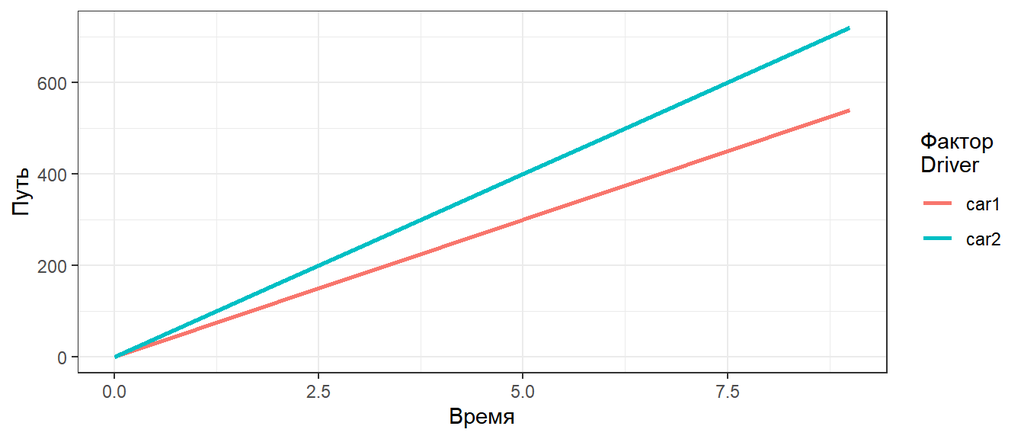

График модели будет разным для двух градаций дискретного фактора.

От значения фактора `Driver` зависит угловой коэффициент модели.

## Формула для усложненной модели

Модель можно представить в виде формулы, но старая формула \(S=Vt\) не годится!

Новая формула:

\[S = (V_1 + b_2 \cdot I_{Driver_2})t\]

- \(V_1\) – Скорость водителя №1
- \(t\) – Время
- \(I_{Driver_2}\) – Переменная-индикатор
- \(b_2\) – Поправочный коэффициент, показывающий на сколько скорость второго водителя отличается от скорости первого.

## Запись модели в привычных обозначениях линейных моделей

Ту же самую модель можно записать в привычных обозначениях, использованных ранее:

\[y = b_1 x + b_2 \cdot I_{Driver_2} \cdot x\]

- \(y\) — зависимая величина (путь)
- \(x\) — предиктор (время)
- \(b_1\) — коэффициент, равный скорости `Водителя_1`
- \(b_2\) — коэффициент, показывающий насколько скорость второго водителя отличается от скорости первого
- \(I_{Driver_2}\) — переменная-индикатор

## Переменная-индикатор (Dummy variable)

\[y = b_1 x + b_2 \cdot I_{Driver_2}\cdot x\]

\(I_{Driver_2}\) — переменная-индикатор:

- \(I_{Driver_2} = 0\) если рассматриваем водителя №1
- \(I_{Driver_2} = 1\) если рассматриваем водителя №2

**Переменные-индикаторы**, или переменные-болванки (dummy variable), “переключают” модель между разными уровнями дискретного фактора.

## Базовый уровень дискретного фактора

У дискретных факторов всегда есть **базовый уровень**.

Базовый уровень — это градация дискретного предиктора, относительно которой вычисляются коэффициенты модели.

В нашей модели в качестве базового уровня фактора `Driver` выбрана градация `Driver_1`.

## Поправочный коэффициент

\[y = b_1 x + b_2 \cdot I_{Driver_2}\cdot x\]

\(b_2\) — поправочный коэффициент, который показывает, **на сколько единиц** (км/ч) отличается скорость `Driver_2` от скорости на базовом уровне (`Driver_1`).

## Формулы для разных уровней

Пусть скорость, которую развивает второй водитель, будет на 20 км/ч выше (\(b_2 = 20\)), чем скорость первого водителя (\(b_1\)).

Модель для `Driver_1` (базовый уровень):

\[ I_{Driver_2}=0 \qquad\qquad y = b_1 x + 20 \cdot 0 \cdot x = b_1 x \qquad\quad \]

Модель для `Driver_2`

\[ I_{Driver_2} = 1 \qquad\qquad y = b_1 x + 20 \cdot 1\cdot x = (b_1 + 20)x \]

## Если уровней становится больше

Предположим, вы бронируете номер в гостинице, где могут быть номера с двумя кроватями (Twin room), с одной большой кроватью (Double room) и семейные номера (Family room).

Модель затрат на оплату проживания в зависимости от времени должна включать дискретный предиктор `Room_type` с тремя градациями: `Twin`, `Double`, `Family`.

## Модель, включающая фактор с несколькими градациями

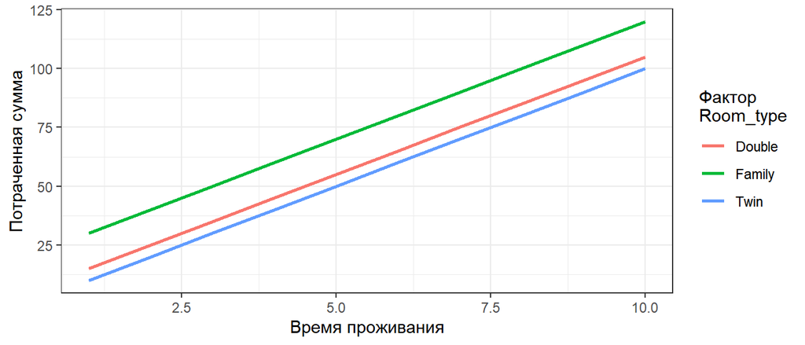

Все три графика параллельны, но одни выше, другие – ниже.

## Уравнение для трех прямых

\(y = b_1 x + b_2 \cdot I_{Double} + b_3 \cdot I_{Family}\)

- \(y\) — зависимая переменная (потраченная сумма)
- \(x\) — непрерывный предиктор (время)
- \(b_1\) — цена одной ночи в номере `Twin` (базовый уровень)
- \(b_2\) — на сколько единиц цена номера `Double` отличается от базового уровня
- \(b_3\) — на сколько единиц цена номера `Family` отличается от базового уровня
- \(I_{Double}, I_{Family}\) — переменные-индикаторы

## Переменные-индикаторы в уравнениях

Общее уравнение:

\[\qquad y = b_1 x_i + b_2 \cdot I_{Double} + b_3 \cdot I_{Family}\]

- Уравнение для проживания в номере типа `Twin` (базовый уровень):

\[y = b_1 x + b_2 \cdot 0 + b_3 \cdot 0 = b_1 \cdot x\]

- Уравнение для проживания в номере типа `Double`:

\[y = b_1 x + b_2 \cdot 1 + b_3 \cdot 0 = b_1 x + b_2\]

- Уравнение для проживания в номере типа `Family`:

\[y = b_1 x + b_2 \cdot 0 + b_3 \cdot 1 = b_1 x + b_3\]

## Отсутствие взаимодействия предикторов

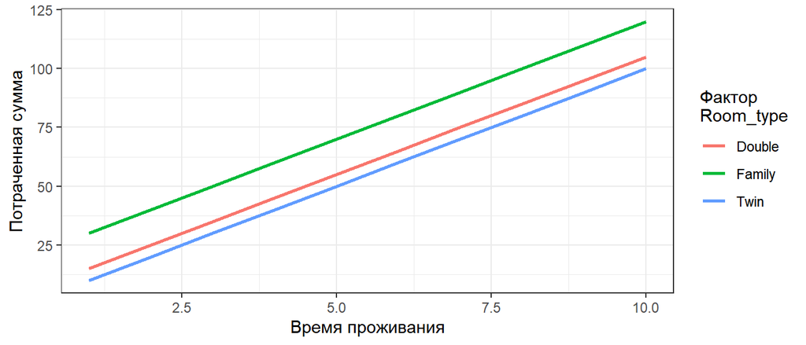

Если характер связи зависимой переменной с непрерывным предиктором одинаков для разных градаций дискретного фактора (прямые параллельны), то говорят, что **между предикторами отсутствует взаимодействие**.

## Взаимодействие предикторов

## Взаимодействие предикторов вокруг нас

Изменение размера счета в банке зависит от уровня доходов человека, от уровня его трат и т.п.

Сумма на банковском счете у людей, занимающих разные должности, разная.

Поэтому модель, описывающая изменение суммы на счете, должна включать дискретный фактор `Position` (Должность).

## Кто-то богатеет, а кто-то не очень

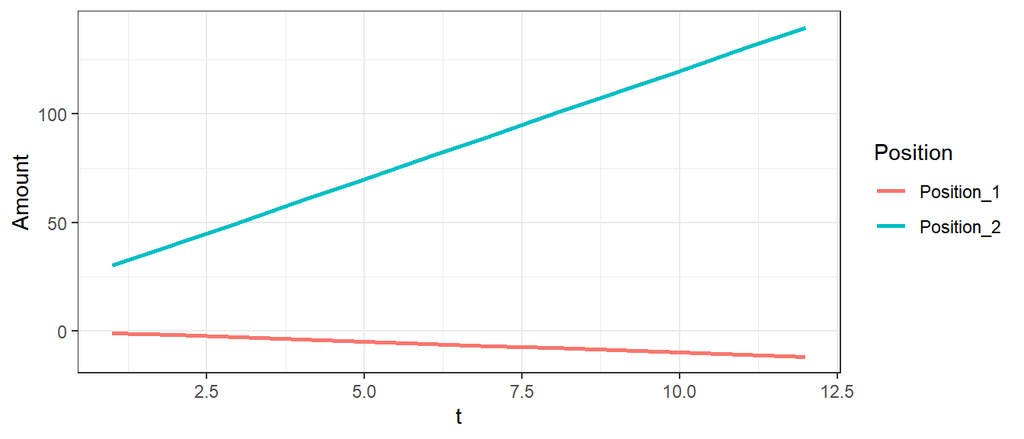

Графики не параллельны – у них различаются как значения свободного члена (intercept), так и угловые коэффициенты (slope).

В такой ситуации говорят, что между дискретным фактором (`Position`, должность) и непрерывным предиктором (`X`, время) существует **взаимодействие**.

## Уравнение модели

\[ y = b_0 + b_1x + b_2 \cdot I_{Position_2} + b_3 \cdot I_{Position_2} \cdot x \]

- \(y\) — зависимая переменная (сумма на банковском счете)
- \(x\) — предиктор (время)
- \(b_0\) — состояние счета работника на должности №1 в начальный момент времени (\(X=0\))
- \(b_1\) — коэффициент, равный доходам (руб/мес) сотрудника на должности №1
- \(I_{Position_2}\) — переменная-индикатор
- \(b_2\) — коэффициент, показывающий, на сколько рублей банковский счет на должности №2 отличается от счета сотрудника на должности №1 в начальный момент времени (\(x = 0\))
- \(b_3\) — на сколько единиц (руб/мес) доходы сотрудника на должности №2 отличаются от доходов сотрудника на должности №1

## Переменные-индикаторы в уравнениях

Общее уравнение:

\[y = b_0 + b_1x + b_2 \cdot I_{Position_2} + b_3 \cdot I_{Position_2} \cdot x\]

- Уравнение для должности №1 (базовый уровень):

\[\begin{aligned}y &= b_0 + b_1x + b_2 \cdot 0 + b_3 \cdot 0 \cdot x = \\ &= b_0 + b_1x\end{aligned}\]

- Уравнение для должности №2:

\[\begin{aligned} y &= b_0 + b_1x + b_2 \cdot 1 + b_3 \cdot 1 \cdot x = \\ &= b_0 + b_1x + b_2 + b_3 \cdot x = \\ &= (b_0 + b_2) + (b_1 + b_3)x \end{aligned}\]

У нас еще будет детальный разговор о взаимодействии дискретных и непрерывных предикторов.

## А как в регрессионных моделях?

Мы рассмотрели простейшие **детерминистские** модели.

В регрессионном анализе все аналогично!

Но есть две особенности:

- В моделях добавляется случайная часть. Они становятся стохастическими.
- Мы заранее не можем сказать, есть ли в изучаемой системе взаимодействие предикторов или его нет. Выявление взаимодействия между предикторами — специальная задача.

## Пример — козы, глисты и линейные модели

## Глистогонные средства и рост коз

Как связан прирост массы коз с начальным весом животного и интенсивностью профилактики паразитарных заболеваний?

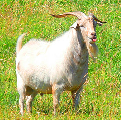

Goat by Jennifer C. [on Flickr](https://flic.kr/p/fjU4J9)

- `Treatment` - обработка от глистов (стандартная, интенсивная)
- `Weightgain` - привес, кг
- `Initial.wt` - начальный вес, кг

Пример из библиотеки данных http://www.statlab.uni-heidelberg.de/data/ancova/goats.story.html

## Читаем данные и знакомимся с ними

```r
library(readxl)
goat <- read_excel("data/goats.xlsx", sheet = 1)
head(goat)
```

```
## # A tibble: 6 × 3
##   Treatment Weightgain `Initial wt`
##   <chr>          <dbl>        <dbl>
## 1 standard           5           21
## 2 standard           3           24
## 3 standard           8           21
## 4 standard           7           22
## 5 standard           6           23
## 6 standard           4           26
```

```r
str(goat)
```

```
## tibble [40 × 3] (S3: tbl_df/tbl/data.frame)
##  $ Treatment : chr [1:40] "standard" "standard" "standard" "standard" ...
##  $ Weightgain: num [1:40] 5 3 8 7 6 4 8 6 7 5 ...
##  $ Initial wt: num [1:40] 21 24 21 22 23 26 22 23 24 20 ...
```

## Читаем данные и знакомимся с ними

```r
colSums(is.na(goat))
```

```
##  Treatment Weightgain Initial wt
##          0          0          0
```

```r
# переименуем переменные для краткости
colnames(goat) <- c("Treatment", "Wt", "Stw")
# объемы выборок
table(goat$Treatment)
```

```
##
## intensive  standard
##        20        20
```

```r
goat$Treatment <- factor(goat$Treatment)
```

## Есть ли выбросы?

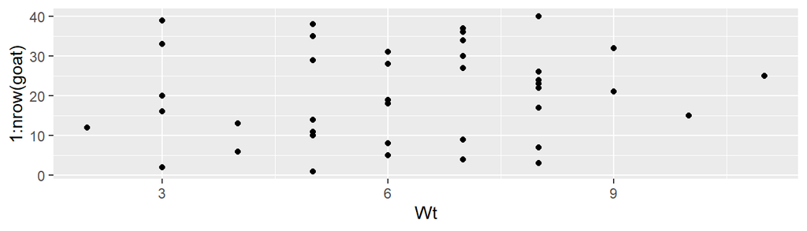

```r
library(ggplot2)
gg_dot <- ggplot(goat, aes(y = 1:nrow(goat))) + geom_point()
gg_dot + aes(x = Wt)
```

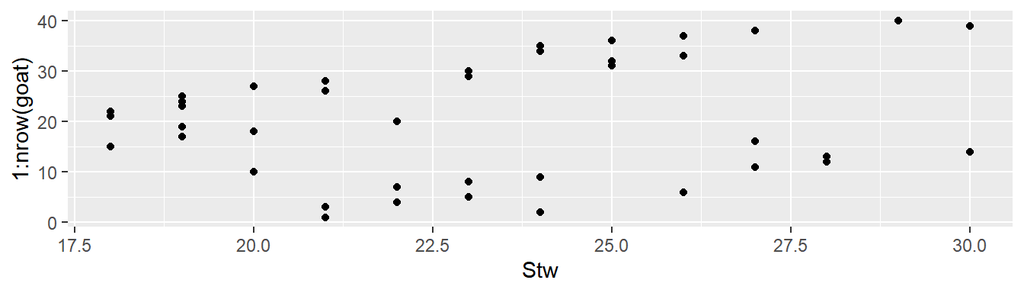

```r
gg_dot + aes(x = Stw)
```

## Строим модель

Нас интересует, как зависит прирост массы коз (`Wt`) от непрерывного предиктора (`Stw`) и дискретного фактора `Treatment`.

Но! Мы не можем сразу решить есть ли в системе взаимодействие или его нет. Поэтому мы должны рассмотреть модель, в которой взаимодействие будет включено.

Зависимость в генеральной совокупности:

\[ Wt_i = \beta_0 + \beta_1Stw_i + \beta_2 \cdot I_{standart\,i} + \beta_3 \cdot I_{standart\,i} \cdot Stw_i + \varepsilon_i, \quad \varepsilon \sim N(0, \sigma) \]

Модель, подобранная по выборке:

\[ Wt_i = b_0 + b_1Stw_i + b_2 \cdot I_{standart\,i} + b_3 \cdot I_{standart\,i} \cdot Stw_i + e_i \]

Предсказанные значения:

\[ \widehat{Wt}_i = b_0 + b_1Stw_i + b_2 \cdot I_{standart\,i} + b_3 \cdot I_{standart\,i} \cdot Stw_i \]

## Строим полную модель

Мы не знаем, взаимодействуют ли дискретный фактор `Treatment` и непрерывный предиктор `Stw`.

Возможна ситуация, при которой худые и жирные козы будут по-разному реагировать на разные типы антигельминтной терапии.

В полной модели мы должны учесть как влияние самих предикторов, так и влияние их взаимодействия.

```r
Mod_goat_full <- lm(Wt ~ Stw + Treatment + Stw:Treatment, data = goat)

# Аналогичная, но более короткая запись
Mod_goat_full <- lm(Wt ~ Stw * Treatment, data = goat)
```

Базовым уровнем фактора будет значение `Treatment` = `intensive`. По умолчанию в R используется первое по алфавиту значение.

## Можно ли не учитывать взаимодействие предикторов?

```r
drop1(Mod_goat_full, test = 'F')
```

```
## Single term deletions
##
## Model:
## Wt ~ Stw * Treatment
##               Df Sum of Sq  RSS  AIC F value Pr(>F)
## <none>                     96.5 43.2
## Stw:Treatment  1     0.342 96.9 41.4    0.13   0.72
```

Значимого взаимодействия не наблюдается!

## Строим сокращенную модель

Формула сокращенной модели

\[ Wt_i = b_0 + b_1Stw_i + b_2 \cdot I_{standart\,i} + e_i \]

\[ \widehat{Wt}_i = b_0 + b_1Stw_i + b_2 \cdot I_{standart\,i} \]

Можно просто переписать формулу.

```r
# Можно просто переписать формулу
Mod_goat_reduced <- lm(Wt ~ Stw + Treatment, data = goat)
```

Но есть более удобный способ.

```r
Mod_goat_reduced <- update(Mod_goat_full, . ~ . - Stw:Treatment)
```

Пока не смотрим в `summary()`!

## Диагностика модели

## Нет ли коллинеарности между начальным весом и типом обработки?

```r
library(car)
vif(Mod_goat_reduced)
```

```
##       Stw Treatment
##         1         1
```

## Нет ли коллинеарности между начальным весом и типом обработки?

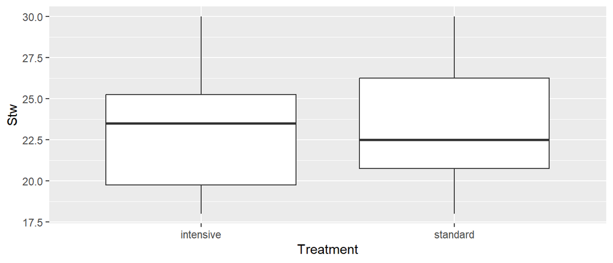

```r
ggplot(goat, aes(x = Treatment, y = Stw)) +
  geom_boxplot()
```

Выраженной коллинеарности нет.

## Строим диагностические графики

```r
MG_diag <- fortify(Mod_goat_reduced)
  Pl_diag1 <- ggplot(MG_diag, aes(x = 1:nrow(MG_diag), y = .cooksd)) +
    geom_bar(stat = 'identity')

  Pl_diag2 <- ggplot(MG_diag, aes(x = .fitted, y = .stdresid)) +
    geom_point() + geom_hline(yintercept = 0)

  Pl_diag3 <- ggplot(MG_diag, aes(x = Stw, y = .stdresid)) +
    geom_point() + geom_hline(yintercept = 0)

  Pl_diag4 <- ggplot(MG_diag, aes(x = Treatment, y = .stdresid)) +
    geom_boxplot()
```

## Строим диагностические графики

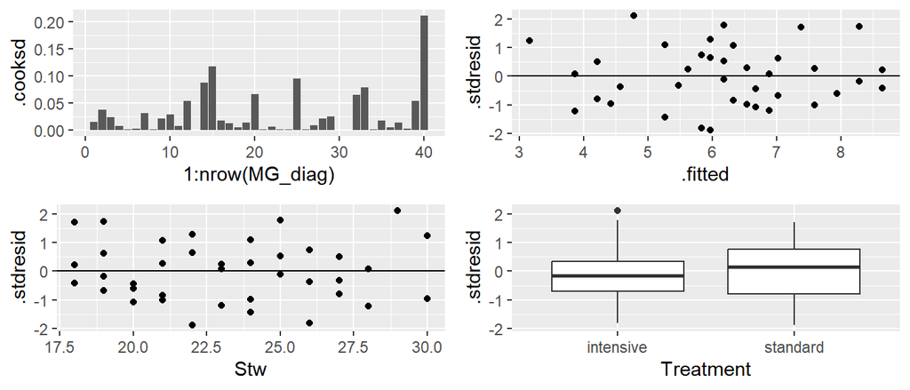

```r
library(cowplot)
plot_grid(Pl_diag1, Pl_diag2, Pl_diag3, Pl_diag4, nrow = 2)
```

Влиятельных наблюдений нет.  
Гетерогенности дисперсий нет.

## Нормальность распределения остатков

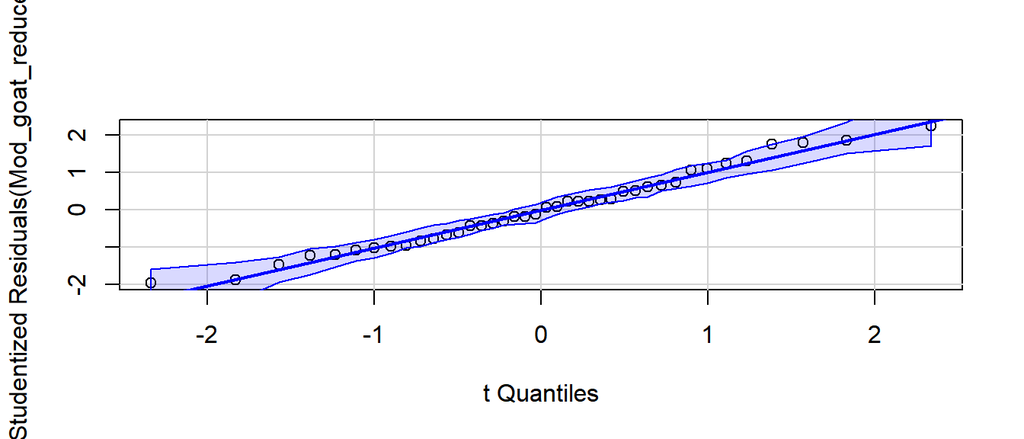

```r
qqPlot(Mod_goat_reduced, id = FALSE) # функция из пакета car
```

## Трактовка регрессионной модели, включающей один дискретный и один непрерывный предиктор

## График модели

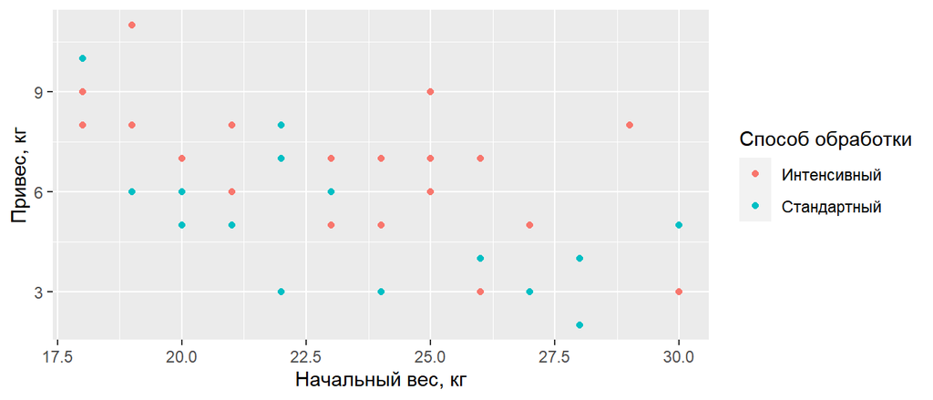

```r
gg_goat <- ggplot(data = goat, aes(y = Wt, x = Stw, colour = Treatment)) +
  geom_point()  +
  labs(x = 'Начальный вес, кг', y = 'Привес, кг') +
  scale_colour_discrete('Способ обработки',
                  breaks = c('intensive', 'standard'),
                  labels = c('Интенсивный', 'Стандартный'))
gg_goat
```

## Добавляем линии регрессии

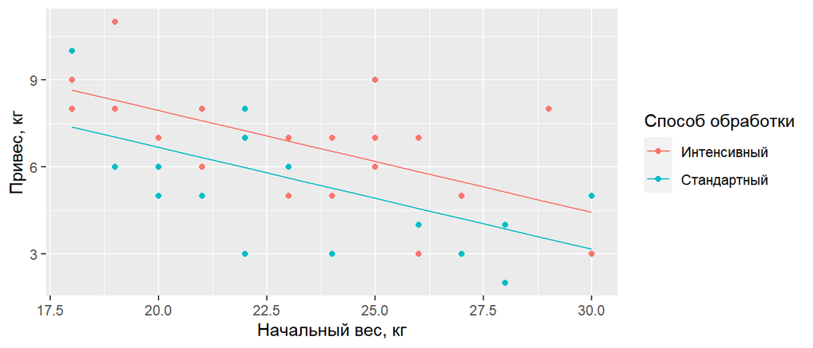

```r
library(dplyr)
new_data <- goat %>% group_by(Treatment)%>%
  do(data.frame(Stw = seq(min(.$Stw), max(.$Stw), length.out = 10)))
new_data$fit = predict(Mod_goat_reduced, newdata = new_data)

gg_goat + geom_line(data = new_data, aes(x = Stw, y = fit, colour = Treatment))
```

## Находим границы доверительной области

```r
# Находим вариационно-ковариационную матрицу для модели Mod_goat_reduced
VC <- vcov(Mod_goat_reduced)

# Модельная матрица
X <- model.matrix(~ Stw + Treatment, data = new_data)

# Стандартные ошибки
new_data$se <- sqrt(diag(X %*% VC %*% t(X)))

# t для расчета 95% доверительного интервала
t_crit <- qt(0.975, df = nrow(goat) - length(coef(Mod_goat_reduced)))
# t для расчета доверит. интервала

# Границы доверительных интервалов
new_data$upr <- new_data$fit + t_crit * new_data$se
new_data$lwr <- new_data$fit - t_crit * new_data$se
```

## Наносим на график границы доверительной области

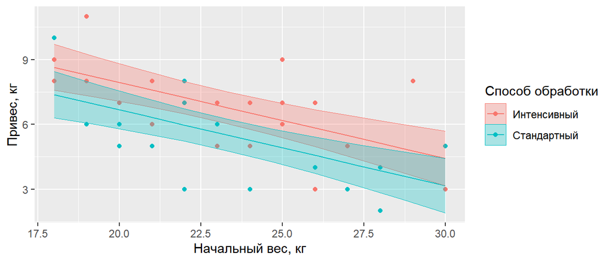

```r
gg_goat + geom_line(data = new_data, aes(x = Stw, y = fit, colour = Treatment)) +
  geom_ribbon(data = new_data,
              aes(x = Stw, y = fit, ymin = lwr, ymax = upr,
                  fill = Treatment), alpha = 0.3, size = 0) +
  scale_fill_discrete('Способ обработки',
                  breaks = c('intensive', 'standard'),
                  labels = c('Интенсивный', 'Стандартный'))
```

## О чем говорят числа в `summary()`

```r
summary(Mod_goat_reduced)
```

```
##
## Call:
## lm(formula = Wt ~ Stw + Treatment, data = goat)
##
## Residuals:
##    Min     1Q Median     3Q    Max
## -2.972 -1.242 -0.034  0.988  3.223
##
## Coefficients:
##                   Estimate Std. Error t value      Pr(>|t|)
## (Intercept)        14.9666     1.7526    8.54 0.00000000028 ***
## Stw                -0.3514     0.0742   -4.73 0.00003207789 ***
## Treatmentstandard  -1.2649     0.5117   -2.47         0.018 *
## ---
## Signif. codes:  0 '***' 0.001 '**' 0.01 '*' 0.05 '.' 0.1 ' ' 1
##
## Residual standard error: 1.62 on 37 degrees of freedom
## Multiple R-squared:  0.438,  Adjusted R-squared:  0.408
## F-statistic: 14.4 on 2 and 37 DF,  p-value: 0.0000233
```

В `summary()` появилась строка `Treatmentstandard`.

Почему не `Treatment`?

## Информация в `summary()` необходима для построения уравнения модели

У нас две линии

Первая: \[Wt = 14.97 - 0.3514 Stw\]

Эта прямая описывает связь между \(Wt\) и \(Stw\) для той градации фактора `Treatment`, которая взята за **базовый уровень**. По умолчанию в качестве базового уровня берется первая по алфавиту градация дискретного фактора. В данном случае - это градация `intensive`

Вторая линия описывает связь между \(Wt\) и \(Stw\) для второй градации фактора `Treatment`. уравнение этой прямой будет таким:

\[ Wt = 14.97 -0.3514 Stw -1.2649 \\ Wt = 13.7 -0.3514 Stw \]

## Смысл коэффициентов при дискретных предикторах

*Смысл 1.*  
Коэффициенты при дискретных предикторах показывают **на сколько единиц** смещается `Intercept` у данного (указанного в `summary()`) уровня по отношению к базовому уровню

*Смысл 2.*  
На сколько единиц отличается среднее значение зависимой переменной для данного (указанного в `summary()`) уровня от среднего значения зависимой переменной для базового уровня.

Уровень значимости в `summary()` говорит о статистической значимости этих отличий (при *попарном* сравнении; если уровней больше двух, то помните про проблемы множественности сравнений)

## Общее уравнение модели

Уравнение приобретает такой вид

\[ Wt = 14.97 - 0.35Stw - 1.26I_{standard} \]

В этом уравнении появилась переменная \(I\) - это переменная-селектор (dummy variable, переменная-болванка)

\(I = 1\) если мы рассматриваем другой уровень дискретного предиктора. В данном случае уровень `Treatment` = “standard”

## Меняем базовый уровень

```r
goat$Treatment <- relevel(goat$Treatment, ref = "standard")
levels(goat$Treatment)
```

```
## [1] "standard"  "intensive"
```

## Строим новую модель

```r
Mod_goat_reduced_2 <- lm(Wt ~ Stw + Treatment, data = goat)
```

## Результаты

```r
summary(Mod_goat_reduced_2)
```

```
##
## Call:
## lm(formula = Wt ~ Stw + Treatment, data = goat)
##
## Residuals:
##    Min     1Q Median     3Q    Max
## -2.972 -1.242 -0.034  0.988  3.223
##
## Coefficients:
##                    Estimate Std. Error t value     Pr(>|t|)
## (Intercept)         13.7017     1.7599    7.79 0.0000000026 ***
## Stw                 -0.3514     0.0742   -4.73 0.0000320779 ***
## Treatmentintensive   1.2649     0.5117    2.47        0.018 *
## ---
## Signif. codes:  0 '***' 0.001 '**' 0.01 '*' 0.05 '.' 0.1 ' ' 1
##
## Residual standard error: 1.62 on 37 degrees of freedom
## Multiple R-squared:  0.438,  Adjusted R-squared:  0.408
## F-statistic: 14.4 on 2 and 37 DF,  p-value: 0.0000233
```

Что изменилось?

## Уравнения

Общее уравнение модели

\[ Wt = 13.7017 -0.3514 Stw + 1.2649 I_{intensive} \] Постройте уравнения для каждого из уровней фактора `Treatment`….

## Как охарактеризовать влияние двух предикторов в целом

```r
library(car)
Anova(Mod_goat_reduced, type = 3)
```

```
## Anova Table (Type III tests)
##
## Response: Wt
##             Sum Sq Df F value        Pr(>F)
## (Intercept)  190.9  1   72.93 0.00000000028 ***
## Stw           58.6  1   22.40 0.00003207789 ***
## Treatment     16.0  1    6.11         0.018 *
## Residuals     96.9 37
## ---
## Signif. codes:  0 '***' 0.001 '**' 0.01 '*' 0.05 '.' 0.1 ' ' 1
```

## Еще раз про суммы квадратов

### SS Type I

- SS(A) для фактора A.
- SS(B | A) для фактора B, при условии, что A уже в модели.
- SS(AB | B, A) для взаимодействия AB.

В этом случае проверяется главный эффект фактора “A”, затем главный эффект фактора “B” после главного эффекта “A”, а затем эффект взаимодействия “AB” после эффектов факторов “A” и “B”.

Из-за последовательного характера и того, что два основных фактора проверяются в определенном порядке, этот тип сумм квадратов даст различные результаты в зависимости от того, какой фактор рассматривается первым.

## Еще раз про суммы квадратов

### SS Type II

- SS(A | B) для фактора A.
- SS(B | A) для фактора B.

Этот тип проверяет каждый главный эффект после другого главного эффекта.

Обратите внимание, что предполагается отсутствие значимого взаимодействия!

Сначала следует проверить значимость взаимодействия (SS(AB | A, B)) и только если AB не является значимым, продолжить анализ главных эффектов.

Если взаимодействие действительно отсутствует, то тип II статистически более эффективен, чем тип III

## Еще раз про суммы квадратов

### SS Type III

- SS(A | B, AB) для фактора A.
- SS(B | A, AB) для фактора B

Этот тип сумм квадратов проверяет наличие главного эффекта при условии, что в модель уже включен второй главный эффект и взаимодействия. Поэтому такой тип суммы квадратов надо применять при наличии значимых взаимодействий.

Однако зачастую интерпретация главного эффекта при наличии взаимодействий не представляет интереса (вообще говоря, при наличии значимого взаимодействия эффекты факторов не должны подвергаться дальнейшему анализу).

Если взаимодействия не значимы, то тип II дает более мощный тест.

## Как охарактеризовать влияние двух предикторов в целом

Поскольку знчимого взаимодействия не выявлено, то можно применить SS Type II.

```r
library(car)
Anova(Mod_goat_reduced, type = 2)
```

```
## Anova Table (Type II tests)
##
## Response: Wt
##           Sum Sq Df F value   Pr(>F)
## Stw         58.6  1   22.40 0.000032 ***
## Treatment   16.0  1    6.11    0.018 *
## Residuals   96.9 37
## ---
## Signif. codes:  0 '***' 0.001 '**' 0.01 '*' 0.05 '.' 0.1 ' ' 1
```

## Вывод:

Привес коз при интенсивной обработке от глистов на 1.26 кг выше, чем при стандартном методе обработки (ANOVA, p =0.018). Привес коз демонстрирует отрицательную связь с начальным весом животного (ANOVA, p < 0.01).

## Общие линейные модели

## Много сторон одной медали

Мы уже рассмотрели довольно много статистических методов:

- Простая регрессия;
- Множественная регрессия;
- Регрессионный анализ с дискретными и непрерывными предикторами.

Все они являются реализациями одного и того же метода — **общие линейные модели**.

**NB!** “Общие линейные модели” (General linear models) нельзя путать с “обобщенными линейными моделями” (Generalized linear models).

## Общий вид линейных моделей

Все разновидности линейных моделей описываются общей формулой

\[ \textbf{y} = \textbf{X} \textbf{b} + \textbf{e} \]

- \(\textbf{y}\) — вектор наблюдаемых значений
- \(\textbf{X}\) — модельная матрица, характеризующая “поведение” предикторов
- \(\textbf{b}\) — вектор коэффициентов модели
- \(\textbf{e}\) — вектор, описывающая случайные отклонения

В случае общих линейных моделей подбор параметров модели (вектор \(\textbf{b}\)) производится **методом наименьших квадратов**.

## Общие линейные модели в матричном виде

\[\mathbf{y} = \mathbf{X} \mathbf{b} + \mathbf{e}\]

\[ \begin{pmatrix} y_1 \\ y_2 \\ \vdots \\ y_n \end{pmatrix} = \begin{pmatrix} 1 & x_{11} & \cdots & x_{p-1\ 1} \\ 1 & x_{12} & \cdots & x_{p-1\ 2} \\ \vdots & & & \\ 1 & x_{1n} & \cdots & x_{p-1\ n} \end{pmatrix} \times \begin{pmatrix} b _0 \\ b _1 \\ b _2 \\ \vdots \\ b_{p-1} \end{pmatrix} + \begin{pmatrix} e _1 \\ e _2 \\ \vdots \\ e _n \end{pmatrix} \]

- \(\mathbf{y}\) — вектор значений зависимой переменной, один столбец в *n* строк (*n* - число наблюдений)
- \(\mathbf{X}\) — модельная матрица с *n* строк. Ее первый столбец содержит единицы, далее по столбцу для каждой из переменных в модели. Количество столбцов равно количеству параметров модели.
- \(\mathbf{b}\) — вектор из \(p\) коэффициентов линейной модели
- \(\mathbf{e}\) — вектор остатков, один столбец в *n* строк

## Разнообразие методов, основанных на общих линейных моделях

Разнообразие методов во многом определяется устройством модельной матрицы \(\textbf{X}\), то есть тем, какова природа предикторов.

- Непрерывные, дискретные и их взаимодействия - Общие линейные модели
- Только непрерывные - Регрессионный анализ
- Только дискретные - Дисперсионный анализ (ANOVA)
- Дискретные и непрерывные, без взаимодействия - Анализ ковариации (ANCOVA)

## Регрессионные модели с непрерывными и дискретными предикторами

Что мы уже о них знаем:

- Принципиальных отличий этой формы линейных моделей от обычной множественной регрессии нет.
- Дискретные предикторы входят в модель, как переменные-индикаторы (dummy-variable).
- Между дискретными и непрерывными предикторами может существовать взаимодействие.
- Наличие взаимодействия необходимо специально оценивать.
- Визуализация таких моделей включает несколько линий регрессии, соответствующих разным градациям дискретного фактора.

## Analysis of covariance (ANCOVA) — частный случай общих линейных моделей

## Ковариата

Иногда влияние дискретного фактора зависит от дополнительной непрерывной переменной — **ковариаты**.

Например, испытывая влияние двух типов удобрений на суммарный урожай на делянках разной площади, мы должны учесть площадь делянки, которую включим в анализ как ковариату.

Площадь делянки — это ковариата.

Важное ограничение: в ANCOVA ковариата не должна взаимодействовать с дискретным предиктором.

## Емкость легких у разных возрастных групп

Различается ли объем легких разных возрастных групп пациентов, которых готовят к операции?

Загрузите с сайта данные `tlc.csv` и поместите файл в папку `data` в рабочей директории.

## Читаем данные

```r
tlc <- read.table('data/tlc.csv', sep = ';', header = TRUE)
str(tlc)
```

```
## 'data.frame':    32 obs. of  4 variables:
##  $ age   : int  35 11 12 16 32 16 14 16 35 33 ...
##  $ sex   : int  1 1 2 1 1 1 1 2 1 1 ...
##  $ height: int  149 138 148 156 152 157 165 152 177 158 ...
##  $ tlc   : num  3.4 3.41 3.8 3.9 4 4.1 4.46 4.55 4.83 5.1 ...
```

Переменные:

- `age` – возраст.
- `sex` – пол (1 - женский; 2 - мужской)
- `height` – рост (см)
- `tlc`– объем легких (л)

## Немного преобразуем исходный датасет

```r
# Создаем переменную, кодирующую возрастную группу
tlc$age_group[tlc$age < 20] <- 'teenagers'
tlc$age_group[tlc$age < 30 & tlc$age >= 20] <- 'young'
tlc$age_group[tlc$age >= 30] <- 'adult'

# Создаем фактор с удобным порядком градаций
tlc$age_group <- factor(tlc$age_group, levels = c('teenagers', 'young', 'adult'))
```

## Как распределены измерения между группами

```r
table(tlc$age_group, tlc$sex)
```

```
##
##             1 2
##   teenagers 4 2
##   young     5 6
##   adult     7 8
```

## В фокусе исследования дискретная переменная

Нас интересует, зависит ли объем легких (`tlc`) от возрастной группы (`age_group`).

То есть модель должна быть основана только на дискретном предикторе с тремя градациями.

Можно ли построить модель такого вида?

\[ tlc_i = b_0 + b_1 \cdot I_{young\,i} + b_3 \cdot I_{adult\,i} + e_i \]

то есть модель должна быть основана только на дискретном предикторе с тремя градациями.

## Нет принципиальной разницы

Моделями с дискретными предикторами занимается **дисперсионный анализ**. С ним мы детально познакомимся позднее.

**НО**! Мы уже знаем, что принципиальной разницы между обычным регрессионным анализом и регрессионным анализом с переменными-индикаторами нет.

## Модель с дискретным предиктором

```r
Mod <- lm(tlc ~ age_group, data = tlc)
summary(Mod)
```

```
##
## Call:
## lm(formula = tlc ~ age_group, data = tlc)
##
## Residuals:
##     Min      1Q  Median      3Q     Max
## -2.6920 -0.6505 -0.0367  0.8625  2.2500
##
## Coefficients:
##                Estimate Std. Error t value     Pr(>|t|)
## (Intercept)       4.037      0.496    8.13 0.0000000057 ***
## age_groupyoung    3.163      0.617    5.13 0.0000178258 ***
## age_groupadult    2.055      0.587    3.50       0.0015 **
## ---
## Signif. codes:  0 '***' 0.001 '**' 0.01 '*' 0.05 '.' 0.1 ' ' 1
##
## Residual standard error: 1.22 on 29 degrees of freedom
## Multiple R-squared:  0.475,  Adjusted R-squared:  0.439
## F-statistic: 13.1 on 2 and 29 DF,  p-value: 0.0000865
```

## Трактовка полученных результатов

Фрагмент вывода функции `summary()`

```
Coefficients:
                 Estimate Std. Error t value     Pr(>|t|)
(Intercept)         4.037      0.496    8.13 0.0000000057 ***
age_groupyoung      3.163      0.617    5.13 0.0000178258 ***
age_groupadult      2.055      0.587    3.50       0.0015 **
```

За базовый уровень взято значение `age_group` = `teenagers`.

Коэффициенты модели показывают, что объем легких у `young` и `adult` при попарном сравнении с базовым уровнем статистически значимо выше, чем объем легких у `teenagers`.

Уравнение модели:

\(\widehat{tlc}_i = 4.037 + 3.163 \cdot I_{young\,i} + 2.055 \cdot I_{adult\,i}\)

## Кодирование дискретных предикторов в R

## Простая регрессионная модель в матричном виде

Мы помним, что модель \(y_i = b_0 + b_1x_i + e_i\) можно записать в матричном виде

\[ \mathbf{y} = \mathbf{X}{\mathbf b} + \mathbf{e} \] или

\[ \widehat{\mathbf{y}} = \mathbf{X}{\mathbf b} \]

Как устроена модельная матрица \(\mathbf{X}\), если в модели только дискретные предикторы?

## Модельная матрица для моделей с дискретными факторами

```r
X <- model.matrix(Mod)
X[c(1:5, 10:15), ]
```

```
##    (Intercept) age_groupyoung age_groupadult
## 1            1              0              1
## 2            1              0              0
## 3            1              0              0
## 4            1              0              0
## 5            1              0              1
## 10           1              0              1
## 11           1              0              1
## 12           1              1              0
## 13           1              1              0
## 14           1              0              1
## 15           1              0              1
```

В колонке `(Intercept)` стоят единицы, как в обычной регрессионной модели.  
В колонке `age_groupyoung` записана первая переменная-индикатор.  
1 — если наблюдение относится к `young`, в остальных случаях — 0.  
В колонке `age_groupadult` записана вторая переменная-индикатор.  
1 — если наблюдение относится к `adult`, в остальных случаях — 0.  
В тех наблюдениях, которые относятся к базовому уровню, везде будет 0.

## Матричное умножение

Вектор коэффициентов

```r
coef(Mod)
```

```
##    (Intercept) age_groupyoung age_groupadult
##           4.04           3.16           2.06
```

Для объекта, относящегося к базовому уровню

```r
X[2,]
```

```
##    (Intercept) age_groupyoung age_groupadult
##              1              0              0
```

\[ \widehat{tlc} = 1 \cdot 4.04 + 0 \cdot 3.16 + 0 \cdot 2.06 = 4.04 \]

\[ \widehat{\mathbf{y}} = \mathbf{X}{\mathbf b} \]

## Матричное умножение

Вектор коэффициентов

```r
coef(Mod)
```

```
##    (Intercept) age_groupyoung age_groupadult
##           4.04           3.16           2.06
```

Для объекта, относящегося к `young`

```r
X[12,]
```

```
##    (Intercept) age_groupyoung age_groupadult
##              1              1              0
```

\[ \widehat{tlc} = 1 \cdot 4.04 + 1 \cdot 3.16 + 0 \cdot 2.06 = 4.04 + 3.16=7.20 \]

\[ \widehat{\mathbf{y}} = \mathbf{X}{\mathbf b} \]

## Матричное умножение

Вектор коэффициентов

```r
coef(Mod)
```

```
##    (Intercept) age_groupyoung age_groupadult
##           4.04           3.16           2.06
```

Для объекта, относящегося к `adult`

```r
X[1, ]
```

```
##    (Intercept) age_groupyoung age_groupadult
##              1              0              1
```

\[ \widehat{tlc} = 1 \cdot 4.04 + 0 \cdot 3.16 + 1 \cdot 2.06 = 4.04 + 2.06=6.10 \]

\[ \widehat{\mathbf{y}} = \mathbf{X}{\mathbf b} \]

## Геометрическая интерпретация линейной модели с дискретным предиктором

## Данные для графика предсказаний модели

Это будет график средних значений зависимой переменной для каждой градации дискретного фактора.

```r
# Создаем искусственный датасет со всеми возможными значениями предиктора
new_data <- data.frame(age_group = factor(levels(tlc$age_group),
                                          levels = levels(tlc$age_group)))
# Предсказанные моделью средние значения зависимой переменной
new_data$fit <- predict(Mod, newdata = new_data, se.fit = TRUE)$fit

# Стандартные ошибки
new_data$se <- predict(Mod, newdata = new_data, se.fit = TRUE)$se.fit

# Критические значения t для расчета доверительных интервалов
t_crit <- qt(0.975, df = nrow(tlc) - length(coef(Mod)))

# Границы доверительных интервалов
new_data$upr <- new_data$fit + t_crit * new_data$se
new_data$lwr <- new_data$fit - t_crit * new_data$se
```

## График предсказаний модели

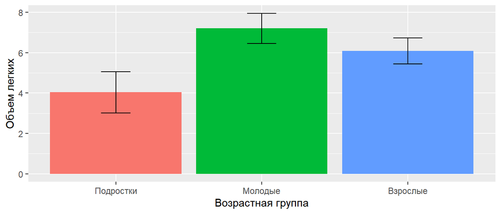

```r
library(ggplot2)
ggplot(new_data, aes(x = age_group, y = fit)) +
  geom_bar(stat = 'identity', aes(fill = age_group)) +
  geom_errorbar(aes(ymin = lwr, ymax = upr), width = 0.2) +
  scale_x_discrete(labels = c('Подростки', 'Молодые', 'Взрослые')) +
  guides(fill = 'none') +
  labs(x = 'Возрастная группа', y = 'Объем легких')
```

## Задание

Проведите диагностику этой модели.

## Можно ли доверять полученным результатам?

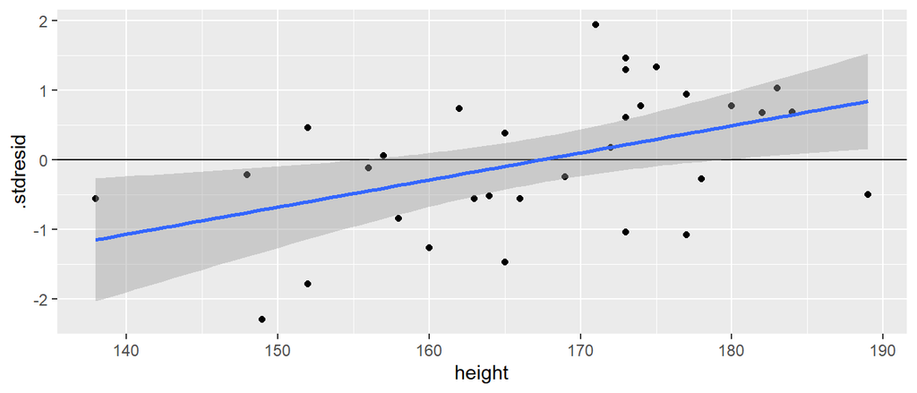

```r
Mod_diag <- fortify(Mod) # Создаем датафрейм с диагностическими данными
Mod_diag$height <- tlc$height # Переменная, не вошедшая в модель

ggplot(Mod_diag, aes(x = height, y = .stdresid)) +
  geom_point() + geom_hline(yintercept = 0) +
  geom_smooth(method = 'lm')
```

Виден очевидный паттерн в остатках!

## В модели необходимо учесть ковариату

Изученные пациенты отличались не только возрастом, но и размером тела (`height`).  
Этот параметр может тоже влиять на объем легких.

Необходимо провести ANCOVA.

## Полная модель с учетом ковариаты

```r
Mod_cov <- lm(tlc ~ age_group * height, data = tlc)
```

В этой модели мы заложили наличие взаимодействия между дискретным и непрерывным предиктором.

ANCOVA подразумевает отсутствие взаимодействия между дискретным предиктором, который находится в фокусе нашего исследования, и ковариатой.

Нужен тест на наличие взаимодействия.

## Присутствует ли взаимодействие?

```r
drop1(Mod_cov, test = 'F')
```

```
## Single term deletions
##
## Model:
## tlc ~ age_group * height
##                  Df Sum of Sq  RSS  AIC F value Pr(>F)
## <none>                        25.8 5.10
## age_group:height  2      2.59 28.4 4.16     1.3   0.29
```

Значимого взаимодействия нет! Можно делать ANCOVA.

## ANCOVA: модель с учетом ковариаты

Модель в ANCOVA ничем не отличается от любой другой регрессионной модели, включающей непрерывные и дискретные предикторы без их взаимодействия.

```r
Mod_cov_2 <- lm(tlc ~ age_group + height, data = tlc)
```

## Модельная матрица в ANCOVA

```r
X <- model.matrix(Mod_cov_2)
head(X)
```

```
##   (Intercept) age_groupyoung age_groupadult height
## 1           1              0              1    149
## 2           1              0              0    138
## 3           1              0              0    148
## 4           1              0              0    156
## 5           1              0              1    152
## 6           1              0              0    157
```

Здесь помимо колонок с переменными-индикаторами (`age_groupyoung` и `age_groupadult`) еще присутствует колонка со значениями непрерывного предиктора (`height`).

Аналогичная модельная матрица будет в любых других регрессионных моделях, включающих непрерывные и дискретные предикторы без их взаимодействия.

## Матричные умножения в ANCOVA

Вектор коэффициентов

```r
coef(Mod_cov_2)
```

```
##    (Intercept) age_groupyoung age_groupadult         height
##        -6.9258         1.8991         0.7197         0.0718
```

Для объекта, относящегося к базовому уровню

```r
X[2, ]
```

```
##    (Intercept) age_groupyoung age_groupadult         height
##              1              0              0            138
```

\[ \widehat{tlc} = 1 \cdot (-6.9258) + 0 \cdot 1.8991 + 0 \cdot 0.7197 + 0.0718 \cdot 138 = 2.98 \]

\[ \widehat{\mathbf{y}} = \mathbf{X}{\mathbf b} \]

## Матричные умножения в ANCOVA

Вектор коэффициентов

```r
coef(Mod_cov_2)
```

```
##    (Intercept) age_groupyoung age_groupadult         height
##        -6.9258         1.8991         0.7197         0.0718
```

Для объекта, относящегося к `young`

```r
X[13, ]
```

```
##    (Intercept) age_groupyoung age_groupadult         height
##              1              1              0            160
```

\[ \widehat{tlc} = 1 \cdot (-6.9258) + 1 \cdot 1.8991 + 0 \cdot 0.7197 + 0.0718 \cdot 160 = 6.46 \]

\[ \widehat{\mathbf{y}} = \mathbf{X}{\mathbf b} \]

## Матричные умножения в ANCOVA

Вектор коэффициентов

```r
coef(Mod_cov_2)
```

```
##    (Intercept) age_groupyoung age_groupadult         height
##        -6.9258         1.8991         0.7197         0.0718
```

Для объекта, относящегося к `adult`

```r
X[1, ]
```

```
##    (Intercept) age_groupyoung age_groupadult         height
##              1              0              1            149
```

\[ \widehat{tlc} = 1 \cdot (-6.9258) + 0 \cdot 1.8991 + 1 \cdot 0.7197 + 0.0718 \cdot 149 = 4.49 \]

\[ \widehat{\mathbf{y}} = \mathbf{X}{\mathbf b} \]

## Диагностика модели в ANCOVA

Нет ли коллинеарности?

```r
library(car)
vif(Mod_cov_2)
```

```
##           GVIF Df GVIF^(1/(2*Df))
## age_group 1.58  2            1.12
## height    1.58  1            1.26
```

Коллинеарности нет.

## График остатков

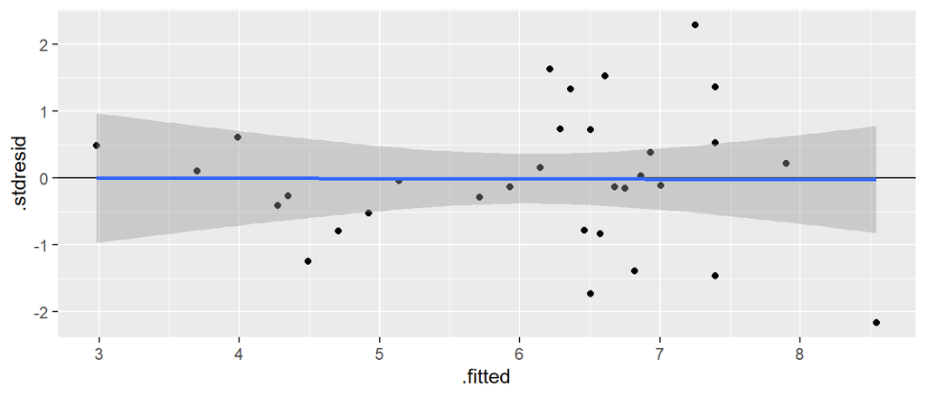

```r
# Датафрейм с диагностическими данными
Mod_cov_2_diag <- fortify(Mod_cov_2)

ggplot(Mod_cov_2_diag, aes(x = .fitted, y = .stdresid)) +
  geom_point() + geom_hline(yintercept = 0) +
  geom_smooth(method = 'lm')
```

Есть намек на гетероскедастичность!

## Остатки в зависимости от непрерывного предиктора

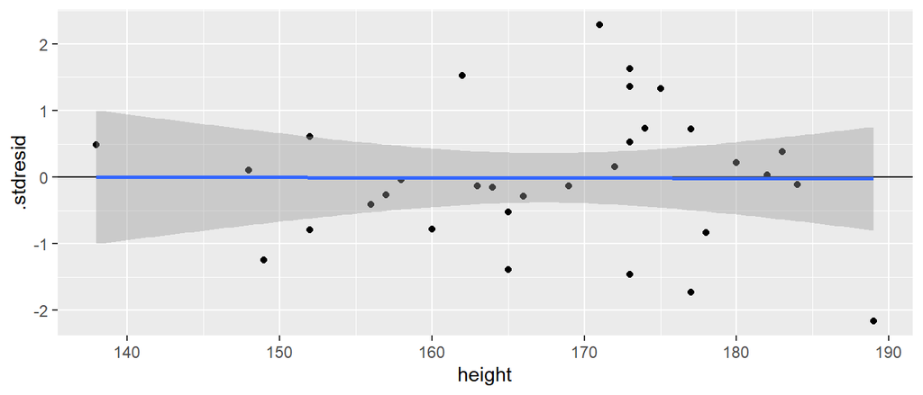

```r
ggplot(Mod_cov_2_diag, aes(x = height, y = .stdresid)) +
  geom_point() +
  geom_hline(yintercept = 0) +
  geom_smooth(method = 'lm')
```

## Остатки в зависимости от дискретного предиктора

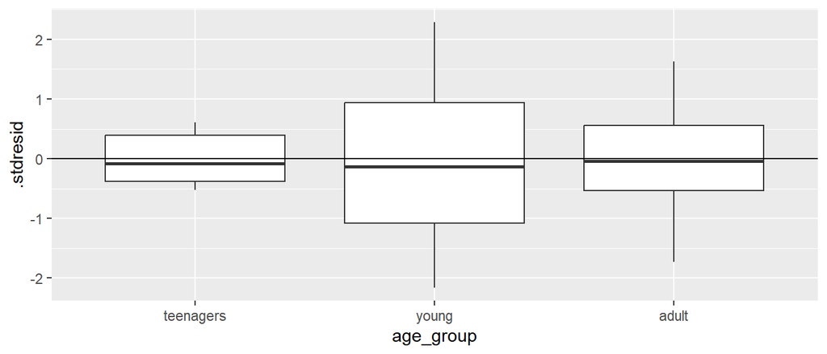

```r
ggplot(Mod_cov_2_diag, aes(x = age_group, y = .stdresid)) +
  geom_boxplot() +
  geom_hline(yintercept = 0)
```

## Результаты ANCOVA

```r
summary(Mod_cov_2)
```

```
##
## Call:
## lm(formula = tlc ~ age_group + height, data = tlc)
##
## Residuals:
##     Min      1Q  Median      3Q     Max
## -1.9247 -0.5238 -0.0729  0.5184  2.1978
##
## Coefficients:
##                Estimate Std. Error t value Pr(>|t|)
## (Intercept)     -6.9258     2.9293   -2.36  0.02523 *
## age_groupyoung   1.8991     0.6107    3.11  0.00427 **
## age_groupadult   0.7197     0.6011    1.20  0.24124
## height           0.0718     0.0190    3.78  0.00076 ***
## ---
## Signif. codes:  0 '***' 0.001 '**' 0.01 '*' 0.05 '.' 0.1 ' ' 1
##
## Residual standard error: 1.01 on 28 degrees of freedom
## Multiple R-squared:  0.653,  Adjusted R-squared:  0.615
## F-statistic: 17.5 on 3 and 28 DF,  p-value: 0.00000132
```

## Трактовка полученных результатов

Фрагмент вывода функции `summary()`

```
Coefficients:
               Estimate Std. Error t value Pr(>|t|)
(Intercept)     -6.9258     2.9293   -2.36  0.02523 *
age_groupyoung   1.8991     0.6107    3.11  0.00427 **
age_groupadult   0.7197     0.6011    1.20  0.24124
height           0.0718     0.0190    3.78  0.00076 ***
```

За базовый уровень взято значение `age_group` = `teenagers`.

Коэффициенты модели показывают, что объем легких при попарном сравнении с базовым уровнем (`teenagers`) статистически значимо выше только у `young`.

Введение в модель ковариаты помогло избежать ложных выводов!

## Тестируем значимость предикторов

Можем воспользоваться частными F-тестами, чтобы протестировать значимость предикторов в целом.

```r
Anova(Mod_cov_2)
```

```
## Anova Table (Type II tests)
##
## Response: tlc
##           Sum Sq Df F value  Pr(>F)
## age_group   13.8  2     6.8 0.00392 **
## height      14.5  1    14.3 0.00076 ***
## Residuals   28.4 28
## ---
## Signif. codes:  0 '***' 0.001 '**' 0.01 '*' 0.05 '.' 0.1 ' ' 1
```

## Сложности визуализации

Модель включает помимо дискретного предиктора еще и непрерывную ковариату.

Предсказания такой модели невозможно представить в виде простой столбчатой диаграммы, отражающей обычные средние значения зависимой переменной для каждой градации фактора.

Необходимо вместо обычных средних использовать **скорректированные средние** (**Adjusted means**).

## Cкорректированные средние

Для их вычисления необходимо принять значение ковариаты за константу (идеально подходит среднее значение ковариаты).

```r
# Создаем искусственный датасет со всеми возможными значениями дискретного предиктора
# и средним значением ковариаты
new_data <- data.frame(age_group = factor(levels(tlc$age_group),
                                          levels = levels(tlc$age_group)),
                       height = mean(tlc$height))
# Предсказанные моделью скорректированные средние значения зависимой переменной
new_data$fit <- predict(Mod_cov_2, newdata = new_data, se.fit = TRUE)$fit

# Стандартные ошибки
new_data$se <- predict(Mod_cov_2, newdata = new_data, se.fit = TRUE)$se.fit
# t для расчета доверительного интервала
t_crit <- qt(0.975, df = nrow(tlc) - length(coef(Mod_cov_2)))
# Границы доверительных интервалов
new_data$upr <- new_data$fit + t_crit * new_data$se
new_data$lwr <- new_data$fit - t_crit * new_data$se
```

## Визуализация модели

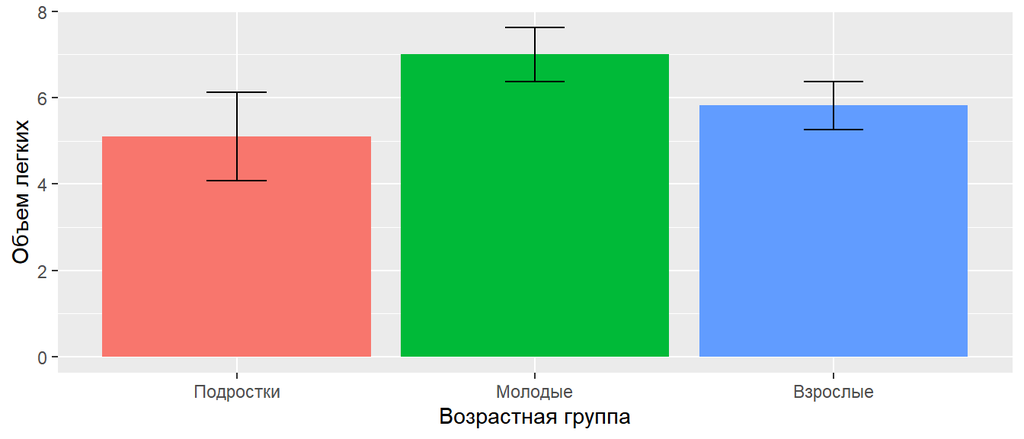

```r
ggplot(new_data, aes(x = age_group, y = fit)) +
  geom_bar(stat = 'identity', aes(fill = age_group)) +
  geom_errorbar(aes(ymin = lwr, ymax = upr), width = 0.2) +
  scale_x_discrete(labels = c('Подростки', 'Молодые', 'Взрослые')) +
  guides(fill = 'none') +
  labs(x = 'Возрастная группа', y = 'Объем легких')
```

## Take home messages

- Нет разницы между моделями с дискретными и непрерывными предикторами
- При анализе влияния дискретного фактора часто необходимо учитывать влияние ковариаты.
- Пр тестировании гипотезы надо помнить о существовании двух типов тестирования: последовательное vs иерархическое.

## Что почитать

- Must read paper! , A.F. and Ieno, E.N., 2016. A protocol for conducting and presenting results of regression‐type analyses. Methods in Ecology and Evolution, 7(6), pp.636-645.
- Кабаков Р.И. R в действии. Анализ и визуализация данных на языке R. М.: ДМК Пресс, 2014
- Zuur, A., Ieno, E.N. and Smith, G.M., 2007. Analyzing ecological data. Springer Science & Business Media.
- Quinn G.P., Keough M.J. 2002. Experimental design and data analysis for biologists
- Logan M. 2010. Biostatistical Design and Analysis Using R. A Practical Guide